# 05 – Interpretation of the XCL1 network: CD8αα(I)/NK → DC1/aDC1

What the CausalCCC network says about the XCL1 → XCR1 relay claim, with the drawings of the network

Author

Jeanne Leclerc, Minh Le

Published

October 18, 2026

## Question

Park *et al.* 2020 (Fig. 4D, fig. S26) write:

> “GNG4⁺CD8αα⁺ T(I) cells expressed XCL1, which may be involved in the recruitment of XCR1-expressing DC1 cells. […] XCL1 is expressed most highly by CD8αα⁺ T(I) cells and at a lower level by NK cells […] a potential relay of signals from CD8αα⁺ T(I) cells to recruit XCR1⁺ DC1 cells into the medulla, where these cells are activated and up-regulate CCR7.”

Notebook 04 built a CausalCCC network with MIIC: 1,000 sender cells (CD8αα(I) and NK, 500 each), 635 receiver cells (DC1 500, aDC1 135), 25 L–R pairs from Table S5 (28 gene–gene links) and five metadata variables per group (population, donor, chemistry, stage and sequencing depth `n_counts`). A first run without sequencing depth is kept for comparison. Here we ask:

1. Sender side: what is the expression of XCL1 associated with – NK or CD8αα(I) population, other genes (section 2)?
2. Receiver side: is XCR1 on DC1 connected to the activation program (CCR7, LAMP3) of aDC1 (section 3)?
3. Which other L–R links connect the same cells to the DC1 program (section 4)?
4. Do the design variables touch the claim’s genes, and what did adding sequencing depth change (section 5)?

Section 6 reads the orientations, section 7 draws the network.

**How to read a CausalCCC network.** Within each group (senders, receivers), a link means that two variables remain dependent whatever other variable of the group is conditioned on; its strength is `info_shifted` (the mutual information, in bits × number of cells, minus a complexity cost). The L–R links between the groups are **given**, not learned: the two genes are never measured in the same cell, so these links only connect the two networks. What can be learned is therefore *what each ligand and each receptor depends on in its own cells*.

## Setup

```r
library(tidyverse)

root <- getwd()
while (!file.exists(file.path(root, "scripts", "helpers.R"))) {
  if (dirname(root) == root) stop("Repository root not found.")
  root <- dirname(root)
}
# link_name(), neighbors_of(), graph_distance(), column_cell_type(), network_data(), plot_network_*()
source(file.path(root, "scripts", "helpers.R"))

res_dir   <- file.path(root, "results", "thymus_case2_xcl1")
files_dir <- file.path(res_dir, "04_causalccc", "causalccc_files")
out_dir   <- file.path(res_dir, "05_interpretation")
fig_dir   <- file.path(root, "results", "figures", "thymus_case2_xcl1")
dir.create(out_dir, recursive = TRUE, showWarnings = FALSE)
dir.create(fig_dir, recursive = TRUE, showWarnings = FALSE)

miic_result  <- readRDS(file.path(res_dir, "04_causalccc", "miic_input", "miic_result.rds"))
# First run, without sequencing depth (same cells, genes and settings; notebook 04)
miic_without <- readRDS(file.path(res_dir, "04_causalccc", "miic_input_without_depth", "miic_result.rds"))
mosaic      <- read_csv(file.path(files_dir, "causalCCC_df.csv"), show_col_types = FALSE, guess_max = Inf)
lr          <- read_tsv(file.path(files_dir, "causalCCC_interactEdges.tsv"), show_col_types = FALSE)

SEND <- "CD8αα(I)/NK"
RECV <- "DC1/aDC1"
META <- c("population", "donor", "method", "stage", "n_counts")

# Cell type of each variable: the group whose rows hold its values
row_type <- if_else(!is.na(mosaic$population_senders), SEND, RECV)
type_of  <- column_cell_type(mosaic, row_type)

# One row per pair of variables (MIIC lists each given L-R link twice, once per direction; notebook 04)
lr_links <- link_name(lr$ligands, lr$receptors)
retained <- function(result) {
  result$all.edges.summary |>
    filter(type == "P") |>
    distinct(pair_a = pmin(x, y), pair_b = pmax(x, y), .keep_all = TRUE) |>
    select(-pair_a, -pair_b) |>
    mutate(is_lr = link_name(x, y) %in% lr_links,
           where = case_when(is_lr ~ "L–R (given)", type_of[x] == SEND ~ "within senders", .default = "within receivers"))
}
edges <- retained(miic_result)
intracellular <- edges |> filter(!is_lr)
edges_without <- retained(miic_without)
intracellular_without <- edges_without |> filter(!is_lr)

# Labels for the tables and drawings: no group suffix, metadata in brackets
var_label <- function(v) {
  label <- str_remove(v, "_(senders|receivers)$")
  if_else(label %in% META, paste0("[", label, "]"), label)
}
# Neighbours of a variable, strongest first, as one string: "gene (strength)"
neighbour_string <- function(v, n = Inf) {
  nb <- intracellular |> filter(x == v | y == v) |>
    transmute(other = if_else(x == v, y, x), info_shifted) |> arrange(desc(info_shifted)) |> head(n)
  if (nrow(nb) == 0) return("–")
  paste0(var_label(nb$other), " (", round(nb$info_shifted), ")", collapse = ", ")
}
degree_of <- function(v) map_int(v, \(g) sum(intracellular$x == g | intracellular$y == g))
```

## 1. Overview of the network

```r
variables <- tibble(variable = names(mosaic), group = type_of[names(mosaic)],
                    kind = if_else(str_remove(names(mosaic), "_(senders|receivers)$") %in% META, "metadata", "gene"))
linked <- unique(c(edges$x, edges$y))

left_join(
  variables |> group_by(group) |>
    summarise(genes = sum(kind == "gene"), metadata = sum(kind == "metadata"),
              variables_linked = sum(variable %in% linked)) |>
    mutate(where = paste("within", if_else(group == SEND, "senders", "receivers"))),
  edges |> group_by(where) |>
    summarise(links = n(), oriented = sum(abs(infOrt) == 2), genuine_causations = sum(is_causal == "Y")),
  by = "where") |>
  bind_rows(edges |> filter(is_lr) |> summarise(where = "L–R (given)", links = n(), oriented = sum(abs(infOrt) == 2),
                                                genuine_causations = sum(is_causal == "Y"))) |>
  select(where, genes, metadata, variables_linked, links, oriented, genuine_causations)
```

```
# A tibble: 3 × 7
  where        genes metadata variables_linked links oriented genuine_causations
  <chr>        <int>    <int>            <int> <int>    <int>              <int>
1 within send…   141        5              146   272       17                  3
2 within rece…   136        5              141   296       36                  6
3 L–R (given)     NA       NA               NA    28        0                  0
```

**Hubs**: the variables with the most learned links in each group.

```r
degrees <- tibble(variable = unique(c(intracellular$x, intracellular$y))) |>
  mutate(group = type_of[variable], degree = degree_of(variable))
degrees |>
  group_by(group) |> slice_max(degree, n = 10, with_ties = FALSE) |>
  mutate(rank = row_number(), label = paste0(var_label(variable), " (", degree, ")")) |>
  select(group, rank, label) |>
  pivot_wider(names_from = group, values_from = label)
```

```
# A tibble: 10 × 3
    rank `CD8αα(I)/NK`     `DC1/aDC1`
   <int> <chr>             <chr>
 1     1 [n_counts] (32)   [n_counts] (21)
 2     2 NKG7 (25)         CD74 (15)
 3     3 [population] (25) CPVL (13)
 4     4 GAPDH (19)        ACTB (11)
 5     5 ACTB (14)         LAMP3 (11)
 6     6 [donor] (13)      [population] (11)
 7     7 MIF (9)           HLA-DPA1 (10)
 8     8 B2M (7)           ARHGDIB (10)
 9     9 EEF1A1 (7)        LYZ (10)
10    10 PFN1 (7)          CFL1 (9)
```

**Strongest learned links** in each group.

```r
intracellular |>
  group_by(where) |> slice_max(info_shifted, n = 10, with_ties = FALSE) |>
  transmute(where, link = paste(var_label(x), "—", var_label(y)), strength = round(info_shifted)) |>
  ungroup()
```

```
# A tibble: 20 × 3
   where            link                  strength
   <chr>            <chr>                    <dbl>
 1 within receivers [donor] — [stage]          514
 2 within receivers HLA-DPA1 — HLA-DPB1        491
 3 within receivers HLA-B — HLA-C              469
 4 within receivers HLA-DPB1 — HLA-DRA         464
 5 within receivers FAU — [n_counts]           449
 6 within receivers MYL6 — PFN1                436
 7 within receivers FAU — UBA52                432
 8 within receivers HLA-A — HLA-B              413
 9 within receivers HLA-DPA1 — HLA-DQB1        410
10 within receivers CFL1 — [n_counts]          407
11 within senders   [donor] — [stage]         1023
12 within senders   NKG7 — [population]        610
13 within senders   [population] — TYROBP      559
14 within senders   [donor] — [method]         508
15 within senders   HLA-B — HLA-C              495
16 within senders   FCER1G — NKG7              495
17 within senders   KLRB1 — NKG7               483
18 within senders   LEF1 — [population]        471
19 within senders   GNB2L1 — [n_counts]        465
20 within senders   B2M — HLA-B                461
```

**Reading.** - Each group holds about 140 genes plus its 5 metadata variables, all of them linked. MIIC kept 272 links among the senders and 296 among the receivers; 53 are oriented and 9 are genuine causations in total. - **Sequencing depth is the first hub of both groups:** `[n_counts]` has 32 links among the senders and 21 among the receivers, with ribosome-associated, translation, cytoskeleton and ATP synthase genes (section 5). - **Senders:** next come NKG7 and `[population]` (25 links each), so the network is organised around depth and around the NK versus CD8αα(I) identity. GAPDH and ACTB remain hubs; the other housekeeping hubs of the first run lost most of their links once depth was a variable (section 5). - **Receivers:** the hubs are CD74 and the MHC class II genes (antigen presentation), CPVL and LYZ (DC1 identity), and LAMP3 and `[population]` (activation, section 3). - **Strongest links:** in both groups, the strongest link is `[donor]`–`[stage]`. Stage is fully determined by donor (section 5), so this link carries no biology. Next come NK identity (NKG7–`[population]`, TYROBP, FCER1G) and depth (GNB2L1–`[n_counts]`) among the senders, and the HLA modules and depth (FAU, CFL1) among the receivers.

## 2. Senders: what XCL1 depends on

```r
tibble(variable = c("XCL1", "XCL2", "population_senders"),
       degree = degree_of(variable),
       neighbours = map_chr(variable, neighbour_string))
```

```
# A tibble: 3 × 3
  variable           degree neighbours
  <chr>               <int> <chr>
1 XCL1                    2 XCL2 (146), [population] (49)
2 XCL2                    3 NKG7 (215), XCL1 (146), CRTAM (52)
3 population_senders     25 NKG7 (610), TYROBP (559), LEF1 (471), KLRD1 (429), …
```

XCL1 by population and stage in the mosaic table (raw counts of the 1,000 sender cells):

```r
mosaic |>
  filter(row_type == SEND) |>
  group_by(population = population_senders, stage = stage_senders) |>
  summarise(cells = n(), XCL1_detected = mean(XCL1 > 0), XCL1_mean = mean(XCL1),
            XCL2_detected = mean(XCL2 > 0), .groups = "drop") |>
  mutate(stage = factor(stage, c("early", "middle", "late"))) |>
  arrange(population, stage) |>
  mutate(across(where(is.double), \(v) round(v, 2)))
```

```
# A tibble: 6 × 6
  population stage  cells XCL1_detected XCL1_mean XCL2_detected
  <chr>      <fct>  <int>         <dbl>     <dbl>         <dbl>
1 CD8αα(I)   early     45          0.36     19.1           0.27
2 CD8αα(I)   middle   226          0.23      9.49          0.13
3 CD8αα(I)   late     229          0.1       1.8           0.05
4 NK         early    310          0.61      3.33          0.87
5 NK         middle   117          0.79      9.79          0.85
6 NK         late      73          0.73      6.77          0.75
```

```r
# Co-expression of XCL1 with XCL2 and with the NK marker NKG7, per sender population
mosaic |>
  filter(row_type == SEND) |>
  group_by(population = population_senders) |>
  summarise(cells = n(),
            `XCL1+ among XCL2+` = mean(XCL1[XCL2 > 0] > 0),
            `XCL1+ among XCL2-` = mean(XCL1[XCL2 == 0] > 0),
            `NKG7 detected` = mean(NKG7 > 0)) |>
  mutate(across(where(is.double), \(v) round(v, 2)))
```

```
# A tibble: 2 × 5
  population cells `XCL1+ among XCL2+` `XCL1+ among XCL2-` `NKG7 detected`
  <chr>      <int>               <dbl>               <dbl>           <dbl>
1 CD8αα(I)     500                0.96                0.09            0.03
2 NK           500                0.71                0.47            0.99
```

**Reading.** - **XCL1 has only two learned neighbours:** XCL2 (146) and `[population]` (49). So in these cells, XCL1 depends on which population the cell belongs to and on XCL2, and on nothing else among the ~140 sender variables, depth included. XCL2 is attached to the NK program (NKG7, 215) and to CRTAM. - **NK cells are the main XCL1 source in this run:** 61–79% of NK cells express it, against 10–36% of CD8αα(I) cells. This agrees with notebook 01: CD8αα(I) leads only on the level within expressing cells. - **In CD8αα(I), XCL1 is carried by a small XCL2⁺ subset:** 96% of XCL2⁺ CD8αα(I) cells express XCL1, against 9% of the others. Since only 3% of CD8αα(I) cells express NKG7, this subset is not contaminating NK cells. Whether it is the GNG4⁺ subset named in the paper is not tested here. - **XCL1 in CD8αα(I) falls with age.** In the run’s cells it goes from 36% (early) to 23% (middle) to 10% (late), but the early value rests on 45 cells. On all CD8αα(I) cells (thymus case 3, notebook 01), it is a drop at birth: 29% of fetal cells against 12% of postnatal cells, with no further decline after birth. In NK cells it goes the other way (61% → 79% → 73%). Yet the network shows **no XCL1–stage (or donor) link**. MIIC tests each dependence on the whole sender group, where these opposite trends probably blur each other. This is a limit of pooling the two populations, which thymus case 3 addresses with CD8αα(I) senders only, fetal and postnatal separately.

## 3. Receivers: XCR1, CCR7 and the activation of DC1

```r
recv_genes <- c("XCR1", "CCR7", "LAMP3", "CD40", "CD80", "CD86", "IL12B", "population_receivers")
tibble(variable = recv_genes, degree = degree_of(variable), neighbours = map_chr(variable, neighbour_string))
```

```
# A tibble: 8 × 3
  variable             degree neighbours
  <chr>                 <int> <chr>
1 XCR1                      2 FGL2 (76), [population] (16)
2 CCR7                      5 [population] (219), SAMSN1 (164), BIRC3 (155), CD…
3 LAMP3                    11 [population] (199), LAD1 (179), EBI3 (177), FSCN1…
4 CD40                      5 LAMP3 (153), SRGN (144), BCL2A1 (144), IL4I1 (110…
5 CD80                      2 LAMP3 (137), BIRC3 (11)
6 CD86                      2 LSP1 (60), SRGN (5)
7 IL12B                     1 LAMP3 (79)
8 population_receivers     11 CCR7 (219), LAMP3 (199), CPVL (174), CD274 (124),…
```

```r
# Number of learned links between XCR1 and the activation genes (within the receivers)
d <- graph_distance(intracellular |> filter(where == "within receivers"), "XCR1")
tibble(from = "XCR1", to = c("population_receivers", "FGL2", "CCR7", "LAMP3", "CD40", "CD80", "CD86", "IL12B", "CD83"),
       links_away = unname(d[to]))
```

```
# A tibble: 9 × 3
  from  to                   links_away
  <chr> <chr>                     <dbl>
1 XCR1  population_receivers          1
2 XCR1  FGL2                          1
3 XCR1  CCR7                          2
4 XCR1  LAMP3                         2
5 XCR1  CD40                          3
6 XCR1  CD80                          3
7 XCR1  CD86                          5
8 XCR1  IL12B                         3
9 XCR1  CD83                          3
```

In the mosaic table, XCR1 and CCR7 are almost mutually exclusive, and both are explained by the DC1 / aDC1 label:

```r
mosaic |>
  filter(row_type == RECV) |>
  mutate(XCR1 = if_else(XCR1 > 0, "XCR1+", "XCR1-"), CCR7 = if_else(CCR7 > 0, "CCR7+", "CCR7-")) |>
  count(population = population_receivers, XCR1, CCR7) |>
  pivot_wider(names_from = c(XCR1, CCR7), values_from = n, values_fill = 0)
```

```
# A tibble: 2 × 5
  population `XCR1+_CCR7+` `XCR1+_CCR7-` `XCR1-_CCR7+` `XCR1-_CCR7-`
  <chr>              <int>         <int>         <int>         <int>
1 DC1                   10           270            10           210
2 aDC1                   3             0           118            14
```

**Reading.** - **XCR1 has two learned neighbours:** FGL2 (76), a DC1 gene, and `[population]` (16). Within the receivers, it does not depend on any activation gene. - **CCR7 and LAMP3 are attached to `[population]`** (219 and 199) and to the activation program of mature DCs: CCR7 to CD83, BIRC3 and SAMSN1; LAMP3 to EBI3, FSCN1, LAD1, CD40, CD80, IL12B, TRAF1 and IL4I1. XCR1 is two links away from CCR7 and LAMP3, and only through the DC1 / aDC1 label; it is three links from CD40, CD80, CD83 and IL12B. - **XCR1 and CCR7 are almost mutually exclusive:** - DC1: 280 of 500 cells express XCR1 and only 20 express CCR7 (10 express both); - aDC1: 121 of 135 express CCR7 and only 3 express XCR1.

**Activation is therefore a switch from an XCR1⁺ state to a CCR7⁺ state.** - **What this supports and what it doesn’t:** it fits the second half of the claim (“activated […] up-regulate CCR7”) as a change of cell state. It gives no evidence that XCL1–XCR1 signalling *causes* this activation: within the receivers, the activation program does not depend on how much XCR1 a cell expresses, and activated cells have lost XCR1. The recruitment “into the medulla” is a spatial statement, which dissociated single-cell data cannot test.

## 4. The other L–R links

For every given link, the learned context of the ligand (in the senders) and of the receptor (in the receivers). A ligand or receptor linked to `[population]` is specific to one of the two populations of its group; a variable with no learned link has no detectable dependence on anything else in the network.

```r
lr_table <- lr |>
  mutate(ligand = var_label(ligands), receptor = var_label(receptors),
         ligand_degree = degree_of(ligands), receptor_degree = degree_of(receptors),
         ligand_to_population = map_lgl(ligands, \(g) "population_senders" %in% neighbors_of(g, intracellular)$neighbor),
         receptor_to_population = map_lgl(receptors, \(g) "population_receivers" %in% neighbors_of(g, intracellular)$neighbor),
         ligand_neighbours = map_chr(ligands, neighbour_string, n = 4),
         receptor_neighbours = map_chr(receptors, neighbour_string, n = 4))
lr_table |>
  select(ligand, receptor, ligand_degree, ligand_to_population, receptor_degree, receptor_to_population,
         ligand_neighbours, receptor_neighbours) |>
  as.data.frame()
```

```
    ligand receptor ligand_degree ligand_to_population receptor_degree
1     XCL1     XCR1             2                 TRUE               2
2     XCL2     XCR1             3                FALSE               2
3      MIF     CD74             9                FALSE              15
4      APP     CD74             1                FALSE              15
5      MIF TNFRSF14             9                FALSE               1
6   LGALS9     CD44             2                FALSE               3
7    KLRF1   CLEC2B             2                 TRUE               3
8     CD28     CD86             2                 TRUE               2
9   CD40LG     CD40             4                FALSE               5
10    IFNG   IFNGR1             1                 TRUE               2
11    IFNG   IFNGR2             1                 TRUE               2
12    CD28     CD80             2                 TRUE               2
13     SPN    ICAM1             2                FALSE               3
14   ITGB1    PLAUR             1                 TRUE               2
```

[output cut: 72 more lines]

```r
lr_table |>
  mutate(ligand_side = case_when(ligand_degree == 0 ~ "isolated",
                                 ligand_to_population ~ "population-specific",
                                 .default = "linked, not to population"),
         receptor_side = case_when(receptor_degree == 0 ~ "isolated",
                                   receptor_to_population ~ "population-specific",
                                   .default = "linked, not to population")) |>
  count(ligand_side, receptor_side)
```

```
# A tibble: 4 × 3
  ligand_side               receptor_side                 n
  <chr>                     <chr>                     <int>
1 linked, not to population linked, not to population    15
2 linked, not to population population-specific           2
3 population-specific       linked, not to population     9
4 population-specific       population-specific           2
```

**Reading.** - **Overview of the 28 links:** - for 15, neither side is tied to the population label; - for 9, only the ligand is population-specific; - for 2, only the receptor is; - for 2, **both sides are: XCL1 → XCR1 and PDCD1 → CD274**. These are the two pairs whose ligand marks one sender population and whose receptor marks one receiver state. - **Costimulation reaches the activation program, XCR1 does not.** - The receptors CD40 and CD80 are direct neighbours of LAMP3, and CD274 (PD-L1) is tied to the aDC1 label. - Their ligands belong to the T-cell module of the senders: CD28 is tied to `[population]` (CD8αα(I) cells), and CD40LG is linked to CD28, ITM2A and CD200. - So the classical T cell–DC pairs CD40LG → CD40, CD28 → CD80 / CD86 and PDCD1 → CD274 connect CD8αα(I) cells to the activated DC1 state more directly than XCL1 → XCR1 does. - Caveat: CD40, CD80 and CD274 are themselves activation markers, so these links reflect co-expression in aDC1 and do not prove signalling. - **CRTAM → CADM1 parallels the XCL axis.** CRTAM is linked to XCL2 (52), and CADM1 to CLEC9A (150), the DC1 marker. CRTAM–CADM1 is a known recognition pair between XCL1-producing cytotoxic cells and cross-presenting DC1, so it points to the same cells as XCL1 → XCR1. - **NK-specific ligands:** IFNG, KLRF1, TIGIT and TNFSF14 are tied to the population label (NK cells). Their receptors are not specific to DC1 or aDC1. - **Depth-driven ligands:** ICAM3 and CD47 are now linked only to `[n_counts]`: their variation among sender cells is explained by sequencing depth. - **Ubiquitous pairs:** MIF and APP → CD74 again rank first in S5 (as in thymus case 1), but the network places MIF in a housekeeping and glycolysis module (GAPDH, GPI, PSMA6) and CD74 in the MHC class II module (HLA-DPA1, HLA-DRB5). Nothing in the network is specific to these pairs. - **Adhesion pairs:** the integrin and adhesion pairs (LFA-1 / ICAM1, VLA-4 / PLAUR, SELL / SELPLG, SPN / ICAM1) sit mostly among cytoskeletal and housekeeping genes. On the receiver side, ICAM1 is linked to NF-κB target genes (SRGN, NFKBIA, BCL2A1).

## 5. Design variables and sequencing depth

```r
# Each donor has a single age, so stage is a function of donor
mosaic |>
  filter(row_type == SEND) |>
  distinct(donor = donor_senders, stage = stage_senders) |>
  count(donor) |>
  summarise(donors = n(), donors_with_one_stage = sum(n == 1))
```

```
# A tibble: 1 × 2
  donors donors_with_one_stage
   <int>                 <int>
1     22                    22
```

```r
tibble(variable = c("donor_senders", "stage_senders", "method_senders", "n_counts_senders",
                    "donor_receivers", "stage_receivers", "method_receivers", "n_counts_receivers"),
       degree = degree_of(variable), neighbours = map_chr(variable, neighbour_string))
```

```
# A tibble: 8 × 3
  variable           degree neighbours
  <chr>               <int> <chr>
1 donor_senders          13 [stage] (1023), [method] (508), NKG7 (316), AC09049…
2 stage_senders           1 [donor] (1023)
3 method_senders          4 [donor] (508), PTPRCAP (311), GABARAP (223), YWHAZ …
4 n_counts_senders       32 GNB2L1 (465), FAU (457), EEF1A1 (456), UBA52 (419),…
5 donor_receivers         6 [stage] (514), HLA-DRB5 (250), [method] (240), HLA-…
6 stage_receivers         1 [donor] (514)
7 method_receivers        4 [donor] (240), NME2 (197), ATP6V0C (31), TMSB4X (17)
8 n_counts_receivers     21 FAU (449), CFL1 (407), COX4I1 (406), GAPDH (394), B…
```

```r
# Distance from the genes of the claim to the design variables (learned links only)
map(c("XCL1", "XCL2", "XCR1", "CCR7"), \(g) {
  d <- graph_distance(intracellular, g)
  side <- if_else(type_of[g] == SEND, "senders", "receivers")
  tibble(gene = g, donor = d[paste0("donor_", side)], stage = d[paste0("stage_", side)],
         chemistry = d[paste0("method_", side)], depth = d[paste0("n_counts_", side)])
}) |> list_rbind()
```

```
# A tibble: 4 × 5
  gene  donor stage chemistry depth
  <chr> <dbl> <dbl>     <dbl> <dbl>
1 XCL1      3     4         4     4
2 XCL2      2     3         3     4
3 XCR1      4     5         5     4
4 CCR7      4     5         5     4
```

**Reading.** - **Stage carries no information beyond donor:** each of the 22 donors of the sender group has a single stage, so `[stage]` links only to `[donor]`. Stage is therefore redundant as a network variable. - **Donor** links to a few genes in each group: - senders: NKG7 (the share of NK cells differs between donors) and some housekeeping genes; - receivers: HLA-DRB5 and HLA-DQA2. These depend on the donor’s HLA haplotype (HLA-DRB5 exists only on DR51-group haplotypes, DR15/DR16), and MIIC orients donor → HLA-DRB5 as a genuine causation, a sensible result. - **Chemistry (3′ / 5′)** links to a handful of genes (PTPRCAP, GABARAP, YWHAZ, NME2, ATP6V0C, TMSB4X), a technical effect. - **Sequencing depth** links to 32 sender genes and 21 receiver genes: - mostly ribosome-associated and translation genes (GNB2L1, FAU, UBA52, EEF1A1, BTF3), cytoskeleton (PFN1, ACTG1, CFL1, TMSB10) and ATP synthase subunits; - and two ligands, ICAM3 and CD47 (section 4). - **The claim’s genes are 2 to 5 links away from donor, stage, chemistry and depth.** So the XCL1, XCL2, XCR1 and CCR7 results above are not direct effects of donor, technology or depth.

### What did adding sequencing depth change?

A first run without `n_counts` is kept for comparison (same cells, genes and settings). Genes that “follow depth” are measured as in Minh’s run A (`notebooks/thymus_early/06_runA_interpretation.qmd`, section 2): median over the populations of the Spearman correlation between the gene’s counts and the total counts of the cell, above 0.5.

```r
pop_col   <- c(setNames("population_senders", SEND), setNames("population_receivers", RECV))
depth_col <- c(setNames("n_counts_senders", SEND), setNames("n_counts_receivers", RECV))
gene_vars <- variables |> filter(kind == "gene") |> pull(variable)
depth_rho <- map_dbl(gene_vars, \(v) {
  t <- type_of[[v]]
  rows <- mosaic[row_type == t, c(v, pop_col[[t]], depth_col[[t]])] |> set_names(c("x", "population", "depth"))
  rhos <- rows |> group_by(population) |>
    summarise(rho = if (sd(x) == 0) NA_real_ else cor(x, depth, method = "spearman")) |> pull(rho)
  median(rhos, na.rm = TRUE)
}) |> setNames(gene_vars)
follows_depth <- names(depth_rho)[!is.na(depth_rho) & depth_rho > 0.5]
tibble(group = type_of[gene_vars], follows = gene_vars %in% follows_depth) |>
  count(group, follows) |> pivot_wider(names_from = follows, values_from = n, names_prefix = "follows_depth_")
```

```
# A tibble: 2 × 3
  group       follows_depth_FALSE follows_depth_TRUE
  <chr>                     <int>              <int>
1 CD8αα(I)/NK                  87                 54
2 DC1/aDC1                     39                 97
```

```r
depth_module <- function(intra) {
  gene_gene <- intra |> filter(x %in% gene_vars, y %in% gene_vars)
  gene_gene |> group_by(where) |>
    summarise(gene_gene_links = n(),
              both_follow_depth = sum(x %in% follows_depth & y %in% follows_depth)) |>
    mutate(share = both_follow_depth / gene_gene_links,
           expected_by_chance = map_dbl(where, \(w) {
             g <- gene_vars[type_of[gene_vars] == if_else(w == "within senders", SEND, RECV)]
             mean(g %in% follows_depth)^2
           }))
}
bind_rows(`without depth` = depth_module(intracellular_without), `with depth` = depth_module(intracellular), .id = "run") |>
  mutate(across(c(share, expected_by_chance), \(v) round(v, 3)))
```

```
# A tibble: 4 × 6
  run           where gene_gene_links both_follow_depth share expected_by_chance
  <chr>         <chr>           <int>             <int> <dbl>              <dbl>
1 without depth with…             272               198 0.728              0.509
2 without depth with…             252               115 0.456              0.147
3 with depth    with…             255               181 0.71               0.509
4 with depth    with…             199                71 0.357              0.147
```

```r
# Links found in both runs, and whether the genes of the claim keep the same neighbours
pairs_of <- function(intra) link_name(intra$x, intra$y)
neighbours_in <- function(intra, v) sort(with(filter(intra, x == v | y == v), if_else(x == v, y, x)))
list(links_in_both = length(intersect(pairs_of(intracellular), pairs_of(intracellular_without))),
     only_without_depth = length(setdiff(pairs_of(intracellular_without), pairs_of(intracellular))),
     only_with_depth = length(setdiff(pairs_of(intracellular), pairs_of(intracellular_without))))
```

```
$links_in_both
[1] 486

$only_without_depth
[1] 99

$only_with_depth
[1] 82
```

```r
tibble(gene = c("XCL1", "XCL2", "XCR1", "CCR7", "LAMP3"),
       same_neighbours = map_lgl(gene, \(v) identical(neighbours_in(intracellular, v), neighbours_in(intracellular_without, v))),
       depth_rho = round(depth_rho[gene], 2))
```

```
# A tibble: 5 × 3
  gene  same_neighbours depth_rho
  <chr> <lgl>               <dbl>
1 XCL1  TRUE                 0.38
2 XCL2  FALSE                0.38
3 XCR1  TRUE                 0.15
4 CCR7  TRUE                 0.38
5 LAMP3 TRUE                 0.41
```

**Reading.** - **Depth removes part of the depth module, not all of it.** Among the senders, the share of gene–gene links joining two depth-following genes falls from 46% to 36% (15% by chance), the same partial effect as in Minh’s run A (34% → 24%). Housekeeping hubs such as SERF2, PPIA and TPT1 lose most of their links; the glycolysis (GAPDH) and cytoskeleton (ACTB) modules stay, so they are not depth effects. - **Among the receivers the measure separates little** (73% → 71%, 51% by chance): 71% of the DC genes follow depth. - **The network is stable** (486 learned links in both runs, 99 and 82 in one only), and **the genes of the claim keep their neighbours** (XCL2 loses only HINT1, a depth-following gene): the results on the claim do not depend on depth. - So `n_counts` is worth including in every run, but a link between two depth-following genes stays weak evidence.

## 6. Orientations and genuine causations

MIIC orients a link when the data contain a v-structure (two variables that are independent but become dependent once a third is known). A “genuine causation” (`is_causal` = Y) is an orientation that cannot be explained by a hidden common cause. Orientations into or out of a metadata variable (a cell label, a donor) are not causal statements about biology: they only record which variables are independent of each other.

```r
oriented <- edges |>
  filter(abs(infOrt) == 2) |>
  transmute(from = if_else(infOrt == 2, x, y), to = if_else(infOrt == 2, y, x), where,
            strength = round(info_shifted), genuine = is_causal,
            involves_metadata = str_detect(paste(from, to), "(population|donor|method|stage|n_counts)_"))
oriented |> count(where, involves_metadata, genuine)
```

```
             where involves_metadata genuine  n
1 within receivers             FALSE       N 25
2 within receivers             FALSE       Y  2
3 within receivers              TRUE       N  5
4 within receivers              TRUE       Y  4
5   within senders             FALSE       N  8
6   within senders             FALSE       Y  2
7   within senders              TRUE       N  6
8   within senders              TRUE       Y  1
```

```r
oriented |>
  filter(genuine == "Y" | str_detect(paste(from, to), "XCL|XCR1|CCR7|LAMP3")) |>
  mutate(from = var_label(from), to = var_label(to)) |>
  arrange(desc(genuine), desc(strength)) |>
  as.data.frame()
```

```
           from           to            where strength genuine
1    [n_counts]       GNB2L1 within receivers      380       Y
2          NKG7        IL2RB   within senders      290       Y
3    [n_counts]        PSME1 within receivers      286       Y
4  [population]        NUCB2   within senders      281       Y
5       [donor]     HLA-DRB5 within receivers      250       Y
6           LYZ        ITGB2 within receivers      198       Y
7    [n_counts]         NPC2 within receivers      187       Y
8          NKG7       ARPC5L   within senders      161       Y
9          PFN1        ACTG1 within receivers       23       Y
10         XCL1 [population]   within senders       49       N
   involves_metadata
1               TRUE
2              FALSE
3               TRUE
4               TRUE
5               TRUE
6              FALSE
7               TRUE
8              FALSE
9              FALSE
10              TRUE
```

**Reading.** - 53 links are oriented: 17 among the senders and 36 among the receivers (65 in the run without depth). - **Genuine causations:** there are 9. - 3 go from `[n_counts]` to a gene (GNB2L1, PSME1, NPC2): depth as a cause of counts, the expected technical direction. - 2 are the same metadata effects as before: `[population]` → NUCB2 and `[donor]` → HLA-DRB5. - 4 are between genes: NKG7 → IL2RB and NKG7 → ARPC5L (NK identity), LYZ → ITGB2 and PFN1 → ACTG1. None has a clear signalling meaning. - Four gene–gene genuine causations of the first run (UBA52 → TMSB4X, GAPDH → TPI1, SERF2 → FAU, GAPDH → COX6C) are gone once depth is a variable: they were depth effects. - **None involves XCL1, XCL2, XCR1 or CCR7.** - **The arrow XCL1 → `[population]` is not causal:** it is a v-structure. XCL1, CD28 and other population-specific genes are independent of each other but each depends on the label, so MIIC points them into it.

## 7. The network, drawn

How to read the drawings: colours are the two groups; diamonds are the centres (XCL1, XCL2, XCR1); dashed lines are the given L–R links (drawn thin, since their strength is set by CausalCCC); an arrowhead is an orientation found by MIIC, and a green link a genuine causation; thicker links are stronger. Metadata variables are in brackets.

```r
# Colours of the two groups for the drawing functions of scripts/helpers.R (which read these two global vectors)
cell_type_colours <- set_names(c("#f2c57c", "#9cc3e6"), c(SEND, RECV))
cell_type_borders <- set_names(c("#a8742a", "#2f6491"), c(SEND, RECV))
centres <- c("XCL1", "XCL2", "XCR1")
claim_net <- network_data(edges, lr_links, type_of, var_label, centres = centres, max_distance = 2)
c(variables = nrow(claim_net$nodes), links = nrow(claim_net$links))
```

```
variables     links
       63        86
```

### The neighbourhood of the claim

All variables at most two learned links away from XCL1, XCL2 or XCR1, and the links among them. Interactive: hover over a node or a link for details, click a node to highlight its neighbours, drag to rearrange, scroll to zoom.

```r
plot_network_interactive(claim_net, title = "XCL1 / XCL2 → XCR1: second-degree neighbourhood", height = "750px")
```

[interactive chart not shown]

Figure 1

The same neighbourhood as a static figure (also saved to `results/figures/thymus_case2_xcl1/05_claim_neighbourhood.png`):

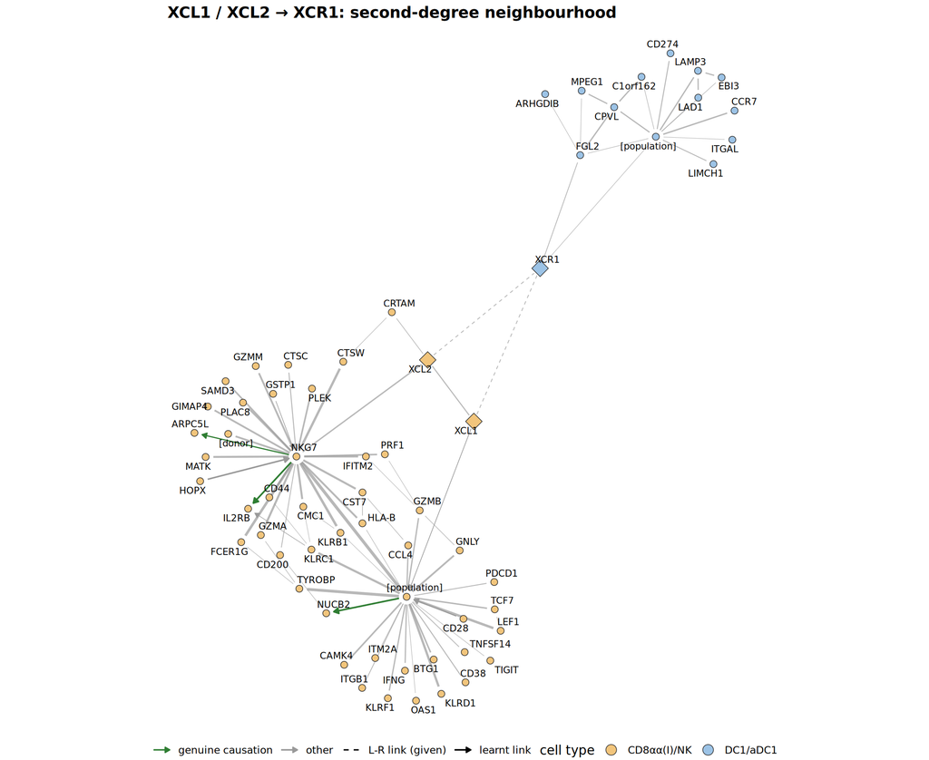

Figure 2

```r
p <- plot_network_static(claim_net, title = "XCL1 / XCL2 → XCR1: second-degree neighbourhood", label_size = 2.8)
ggsave(file.path(fig_dir, "05_claim_neighbourhood.png"), p, width = 11, height = 9, dpi = 200)
p
```

### The whole network

All retained links. With about 287 variables the drawing is dense: zoom in, or click a gene to highlight its neighbours.

```r
network_data(edges, lr_links, type_of, var_label) |>
  plot_network_interactive(title = "CD8αα(I)/NK → DC1/aDC1: all links", height = "850px")
```

[interactive chart not shown]

Figure 3

```r
# Retained links with their group and labels, for later notebooks
edges |>
  transmute(x, y, x_label = var_label(x), y_label = var_label(y), where, is_lr, info_shifted, infOrt, is_causal) |>
  write_csv(file.path(out_dir, "retained_links.csv"))
lr_table |> select(-ligands, -receptors) |> write_csv(file.path(out_dir, "lr_links_context.csv"))
list.files(out_dir)
```

```
[1] "lr_links_context.csv" "retained_links.csv"
```

## Summary

| Question | Answer from the network |
| --- | --- |
| XCL1, sender side | Linked only to XCL2 and to the population label; NK cells are the main source (61–79% of cells against 10–36% of CD8αα(I)); in CD8αα(I), a small XCL1⁺XCL2⁺ subset, 29% of fetal against 12% of postnata… |
| XCR1 → DC1 activation, receiver side | XCR1 (resting DC1) and CCR7 / LAMP3 (aDC1) are almost mutually exclusive and connected only through the DC1 / aDC1 label; the activation program does not depend on XCR1 |
| Other L–R links | Costimulation from CD8αα(I) (CD40LG → CD40, CD28 → CD80 / CD86, PDCD1 → CD274) reaches the aDC1 program more directly than XCL1 → XCR1; CRTAM → CADM1 links the XCL2⁺ cytotoxic program to CLEC9A⁺ DC1; … |
| Design variables, depth | Donor and chemistry do not touch the claim’s genes; stage is redundant with donor; depth absorbs part of the sender housekeeping module (46% → 36% of gene–gene links) without changing the results on t… |

**What this means for the claim.** The network reproduces the *expression* part of the claim only in part: XCL1 is specific to the senders, but NK cells, not CD8αα(I) cells, are its main source in this object (“most highly” holds only for the level within expressing cells, notebook 01). The *relay* part (XCR1⁺ DC1 recruited, then activated) is consistent as a change of state, but not shown as a consequence of XCL1 signalling; recruitment into the medulla cannot be tested on dissociated cells. The costimulation and CRTAM → CADM1 pairs are known thymocyte–DC signals (Oh *et al.*, *J Immunol* 2018, [doi:10.4049/jimmunol.1700768](https://doi.org/10.4049/jimmunol.1700768); Srinivasan *et al.*, *Nat Immunol* 2026, [doi:10.1038/s41590-025-02371-9](https://doi.org/10.1038/s41590-025-02371-9); Arase *et al.*, *Int Immunol* 2005, [doi:10.1093/intimm/dxh299](https://doi.org/10.1093/intimm/dxh299); Galibert *et al.*, *J Biol Chem* 2005, [doi:10.1074/jbc.M502095200](https://doi.org/10.1074/jbc.M502095200)); thymus case 3 (notebook 05, section 8) discusses them, and the XCL1–TNFRSF9 association, against the literature.

**Limits.** The L–R links are given, not inferred. Pooling NK and CD8αα(I) cells hides the drop of XCL1 at birth in CD8αα(I), because NK cells go the opposite way: thymus case 3 (`notebooks/thymus_case3_xcl1_age/`) runs CD8αα(I) senders only, fetal and postnatal separately. Sequencing depth also removed four genuine causations of the first run among the senders.

**Possible next steps.** - A check of GNG4 in the XCL1⁺ CD8αα(I) subset. - The same analysis on the authors’ T-cell object (finer annotation), which fig. S26 was drawn from.

**Outputs:** - `results/thymus_case2_xcl1/05_interpretation/retained_links.csv`: every link, with group and labels; - `results/thymus_case2_xcl1/05_interpretation/lr_links_context.csv`: the context of each L–R link; - `results/figures/thymus_case2_xcl1/05_claim_neighbourhood.png`: the static figure.